# Мой ежедневный прогресс: SQL, Python, профессиональная литература

# Содержание

## Описание проекта 👩‍💻

В данном проекте проводится фиксация, измерение и анализ моего ежедневного прогресса в занятиях SQL, Python и чтении профессиональной литературы.

**Основные задачи**:

- отследить и измерить свой прогресс в обучении
- выявить среднюю скорость и средний объём изучаемого материала на ежедневной основе
- автоматически вычислять и ежедневно корректировать KPI с учётом оставшегося объёма и времени до предполагаемой финальной даты
- визуализировать собранные данные, сделать прогресс наглядным
- мотивировать себя к продолжению ежедневных занятий :-)
- помочь себе освоить весь намеченный материал в срок

**Описание данных**:

- по решению задач на SQL-ex,
- по прохождению курса "Поколение Python" на платформе Stepic,
- чтению профессиональной литературы и практики английского,
- также в дневнике зафиксированы другие профессиональные активности, например, решение тестовых заданий, собеседования, отклики
- дополнительные курсы (например, Karpov courses)

В процессе ведения дневника была поставлена цель: освоить курсы на Stepic и Karpov courses, а также дочитать начатые книги до 3 июля (эта дата - окончание отпуска в Акселерации Яндекс Практикума).

## Открытие данных

Импортируем необходимые библиотеки:

```python
import pandas as pd
import os

from matplotlib import pyplot as plt
import matplotlib.gridspec as gridspec
import matplotlib.ticker as mticker
import seaborn as sns

import datetime as dt

import warnings
warnings.filterwarnings("ignore")
```

Открываем файл:

```python
if os.path.exists('/datasets/my_daily_progress.xlsx'):
    df = pd.read_excel('/datasets/my_daily_progress.xlsx')
else:
    df = pd.read_excel('/C:/datasets/my_daily_progress.xlsx')
```

Для ознакомления и проверки данных будем использовать собственную функцию:

```python
def my_check_function (dataset):
    '''Функция для ознакомления и проверки даных'''
    print('Размер датасета (количество строк, столбцов):')
    print(dataset.shape)
    print('Как выглядят случайные 5 строк:')
    display(dataset.sample(5, random_state=42))
    print()
    print('Общая информация о данных, наименования столбцов, типы данных:')
    print(dataset.info())
    print()
    print('Есть ли пропуски, сколько их:')
    print(dataset.isna().sum())
    print('Доля пропущенных значений:')
    print(dataset.isna().mean())
    print()
    print('Есть ли явные дубликаты, сколько их:')
    print(dataset.duplicated().sum())
    print('Доля явных дубликатов:')
    print(dataset.duplicated().mean())
    print()
    print('Подробное описание данных:')
    display(dataset.describe())
```

```python
my_check_function(df)
```

```
Размер датасета (количество строк, столбцов):
(44, 28)
Как выглядят случайные 5 строк:
```

|  | date | sqlex_chapter_name | sqlex_last_solved_task_number | sqlex_total_task_number | platform_name | course_name | course_current | course_total | stepic_python_current | stepic_python_total | ... | eng_total_page | eng_podcast_name | eng_podcast_minutes | eng_new_words_in_reword | show_name | serial_count | career_activity_type | career_activity_number | career_activity_description | career_source |
| --- | --- | --- | --- | --- | --- | --- | --- | --- | --- | --- | --- | --- | --- | --- | --- | --- | --- | --- | --- | --- | --- |
| 37 | 2023-06-25 | SELECT (обучающий этап) | 65 | 190 | Karpov courses | Симулятор SQL | 121.0 | 138.0 | 1888.0 | 2049.0 | ... | 192.0 | IELTS Speaking for Success | 0.0 | 5 | Fargo | 1.0 | NaN | NaN | NaN | NaN |
| 24 | 2023-06-12 | SELECT (обучающий этап) | 53 | 190 | Karpov courses | Симулятор SQL | 42.0 | 138.0 | 763.0 | 2049.0 | ... | NaN | NaN | NaN | 5 | Severance | 0.0 | NaN | NaN | NaN | NaN |
| 25 | 2023-06-13 | SELECT (обучающий этап) | 54 | 190 | Karpov courses | Симулятор SQL | 65.0 | 138.0 | 804.0 | 2049.0 | ... | 192.0 | NaN | NaN | 5 | Severance | 1.0 | отказ | 1.0 | NaN | Kit Soler |
| 36 | 2023-06-24 | SELECT (обучающий этап) | 64 | 190 | Karpov courses | Симулятор SQL | 119.0 | 138.0 | 1805.0 | 2049.0 | ... | 192.0 | IELTS Speaking for Success | 0.0 | 5 | Fargo | 1.0 | NaN | NaN | NaN | NaN |
| 34 | 2023-06-22 | SELECT (обучающий этап) | 62 | 190 | Karpov courses | Симулятор SQL | 109.0 | 138.0 | 1686.0 | 2049.0 | ... | 192.0 | IELTS Speaking for Success | 30.0 | 5 | Fargo | 1.0 | отклики | 1.0 | Valiotti Analytics | NaN |

5 rows × 28 columns

```
Общая информация о данных, наименования столбцов, типы данных:
<class 'pandas.core.frame.DataFrame'>
RangeIndex: 44 entries, 0 to 43
Data columns (total 28 columns):
 #   Column                         Non-Null Count  Dtype
---  ------                         --------------  -----
 0   date                           44 non-null     datetime64[ns]
 1   sqlex_chapter_name             44 non-null     object
 2   sqlex_last_solved_task_number  44 non-null     int64
 3   sqlex_total_task_number        44 non-null     int64
 4   platform_name                  23 non-null     object
 5   course_name                    23 non-null     object
 6   course_current                 23 non-null     float64
 7   course_total                   23 non-null     float64
 8   stepic_python_current          41 non-null     float64
 9   stepic_python_total            41 non-null     float64
 10  book_name                      31 non-null     object
 11  book_author                    31 non-null     object
 12  current_page                   31 non-null     float64
 13  total_page                     31 non-null     float64
 14  eng_book_name                  18 non-null     object
 15  eng_book_author                18 non-null     object
 16  eng_current_page               18 non-null     float64
 17  eng_end_page                   18 non-null     float64
 18  eng_total_page                 18 non-null     float64
 19  eng_podcast_name               10 non-null     object
 20  eng_podcast_minutes            10 non-null     float64
 21  eng_new_words_in_reword        44 non-null     int64
 22  show_name                      42 non-null     object
 23  serial_count                   42 non-null     float64
 24  career_activity_type           9 non-null      object
 25  career_activity_number         9 non-null      float64
 26  career_activity_description    7 non-null      object
 27  career_source                  8 non-null      object
dtypes: datetime64[ns](1), float64(12), int64(3), object(12)
memory usage: 9.8+ KB
None

Есть ли пропуски, сколько их:
date                              0
```

[output cut: 50 more lines]

```
eng_new_words_in_reword          0.000000
show_name                        0.045455
serial_count                     0.045455
career_activity_type             0.795455
career_activity_number           0.795455
career_activity_description      0.840909
career_source                    0.818182
dtype: float64

Есть ли явные дубликаты, сколько их:
0
Доля явных дубликатов:
0.0

Подробное описание данных:
```

|  | sqlex_last_solved_task_number | sqlex_total_task_number | course_current | course_total | stepic_python_current | stepic_python_total | current_page | total_page | eng_current_page | eng_end_page | eng_total_page | eng_podcast_minutes | eng_new_words_in_reword | serial_count | career_activity_number |
| --- | --- | --- | --- | --- | --- | --- | --- | --- | --- | --- | --- | --- | --- | --- | --- |
| count | 44.000000 | 44.0 | 23.000000 | 23.0 | 41.000000 | 41.0 | 31.000000 | 31.000000 | 18.000000 | 18.000000 | 18.0 | 10.000000 | 44.0 | 42.000000 | 9.000000 |
| mean | 44.159091 | 190.0 | 92.608696 | 138.0 | 715.487805 | 2049.0 | 125.129032 | 442.967742 | 108.277778 | 135.333333 | 192.0 | 24.000000 | 5.0 | 0.880952 | 4.555556 |
| std | 19.573289 | 0.0 | 40.591915 | 0.0 | 663.377537 | 0.0 | 106.684814 | 167.245824 | 6.304112 | 29.517692 | 0.0 | 12.649111 | 0.0 | 0.308607 | 4.530759 |
| min | 0.000000 | 190.0 | 0.000000 | 138.0 | 0.000000 | 2049.0 | 0.000000 | 164.000000 | 98.000000 | 120.000000 | 192.0 | 0.000000 | 5.0 | 0.000000 | 1.000000 |
| 25% | 29.500000 | 190.0 | 80.500000 | 138.0 | 120.000000 | 2049.0 | 72.500000 | 352.000000 | 104.000000 | 120.000000 | 192.0 | 30.000000 | 5.0 | 1.000000 | 1.000000 |
| 50% | 48.500000 | 190.0 | 103.000000 | 138.0 | 534.000000 | 2049.0 | 94.000000 | 540.000000 | 107.000000 | 120.000000 | 192.0 | 30.000000 | 5.0 | 1.000000 | 1.000000 |
| 75% | 60.250000 | 190.0 | 122.500000 | 138.0 | 1042.000000 | 2049.0 | 155.000000 | 540.000000 | 113.500000 | 120.000000 | 192.0 | 30.000000 | 5.0 | 1.000000 | 10.000000 |
| max | 71.000000 | 190.0 | 138.000000 | 138.0 | 2049.000000 | 2049.0 | 540.000000 | 540.000000 | 120.000000 | 189.000000 | 192.0 | 30.000000 | 5.0 | 1.000000 | 11.000000 |

**Вывод**:

Необходимые библиотеки загружены, а данные открыты, проверены и готовы к работе.

## Предобработка и добавление новых данных

Заполним пропуски:

```python
df['career_activity_type'] = df['career_activity_type'].fillna('нет')
df['career_activity_description'] = df['career_activity_description'].fillna('нет')
df['career_source'] = df['career_source'].fillna('нет')
```

Вставим ежедневные счётчики и процент пройденного по всем направлениям:

```python
# SQL-ex
(df.insert(2, 'sqlex_day_cnt',
           df['sqlex_last_solved_task_number'] - df['sqlex_last_solved_task_number'].shift(1)))
df.insert(5, 'sqlex_percent', df['sqlex_last_solved_task_number']/df['sqlex_total_task_number']*100)

# доп.курсы
(df.insert(8, 'course_day_cnt',
           df['course_current'] - df['course_current'].shift(1)))
df.insert(11, 'course_percent', df['course_current']/df['course_total']*100)

# Stepic Python
(df.insert(12, 'stepic_python_day_cnt',
           df['stepic_python_current'] - df['stepic_python_current'].shift(1)))
df.insert(15, 'stepic_percent', df['stepic_python_current']/df['stepic_python_total']*100)

# проф.литература
(df.insert(18, 'book_day_cnt',
           df['current_page'] - df['current_page'].shift(1)))
df.insert(21, 'book_percent', df['current_page']/df['total_page']*100)

# практика англ.
(df.insert(24, 'eng_book_day_cnt',
           df['eng_current_page'] - df['eng_current_page'].shift(1)))
df.insert(27, 'eng_book_percent', df['eng_current_page']/df['eng_end_page']*100)
```

Обработаем исключительные случаи:

```python
df.loc[df['book_day_cnt'] < 0, 'book_day_cnt'] = df.loc[df['book_day_cnt'] < 0]['current_page']
df.loc[df['eng_book_day_cnt'] < 0, 'eng_book_day_cnt'] = df.loc[df['eng_book_day_cnt'] < 0]['eng_current_page']

df.loc[df['course_day_cnt'] < 0, 'course_day_cnt'] = df.loc[df['course_day_cnt'] < 0]['course_current']
```

Проверим, как это выглядит:

```python
pd.set_option('display.max_columns', None)
df
```

|  | date | sqlex_chapter_name | sqlex_day_cnt | sqlex_last_solved_task_number | sqlex_total_task_number | sqlex_percent | platform_name | course_name | course_day_cnt | course_current | course_total | course_percent | stepic_python_day_cnt | stepic_python_current | stepic_python_total | stepic_percent | book_name | book_author | book_day_cnt | current_page | total_page | book_percent | eng_book_name | eng_book_author | eng_book_day_cnt | eng_current_page | eng_end_page | eng_book_percent | eng_total_page | … |
| --- | --- | --- | --- | --- | --- | --- | --- | --- | --- | --- | --- | --- | --- | --- | --- | --- | --- | --- | --- | --- | --- | --- | --- | --- | --- | --- | --- | --- | --- | --- |
| 0 | 2023-05-19 | SELECT (обучающий этап) | NaN | 0 | 190 | 0.000000 | NaN | NaN | NaN | NaN | NaN | NaN | NaN | 0.0 | 2049.0 | 0.000000 | NaN | NaN | NaN | NaN | NaN | NaN | NaN | NaN | NaN | NaN | NaN | NaN | NaN | … |
| 1 | 2023-05-20 | SELECT (обучающий этап) | 8.0 | 8 | 190 | 4.210526 | NaN | NaN | NaN | NaN | NaN | NaN | 0.0 | 0.0 | 2049.0 | 0.000000 | NaN | NaN | NaN | NaN | NaN | NaN | NaN | NaN | NaN | NaN | NaN | NaN | NaN | … |
| 2 | 2023-05-21 | SELECT (обучающий этап) | 2.0 | 10 | 190 | 5.263158 | NaN | NaN | NaN | NaN | NaN | NaN | 20.0 | 20.0 | 2049.0 | 0.976086 | NaN | NaN | NaN | NaN | NaN | NaN | NaN | NaN | NaN | NaN | NaN | NaN | NaN | … |
| 3 | 2023-05-22 | SELECT (обучающий этап) | 3.0 | 13 | 190 | 6.842105 | NaN | NaN | NaN | NaN | NaN | NaN | 15.0 | 35.0 | 2049.0 | 1.708150 | NaN | NaN | NaN | NaN | NaN | NaN | NaN | NaN | NaN | NaN | NaN | NaN | NaN | … |
| 4 | 2023-05-23 | SELECT (обучающий этап) | 3.0 | 16 | 190 | 8.421053 | NaN | NaN | NaN | NaN | NaN | NaN | 7.0 | 42.0 | 2049.0 | 2.049780 | NaN | NaN | NaN | NaN | NaN | NaN | NaN | NaN | NaN | NaN | NaN | NaN | NaN | … |
| 5 | 2023-05-24 | SELECT (обучающий этап) | 2.0 | 18 | 190 | 9.473684 | NaN | NaN | NaN | NaN | NaN | NaN | 18.0 | 60.0 | 2049.0 | 2.928258 | NaN | NaN | NaN | NaN | NaN | NaN | NaN | NaN | NaN | NaN | NaN | NaN | NaN | … |
| 6 | 2023-05-25 | SELECT (обучающий этап) | 2.0 | 20 | 190 | 10.526316 | NaN | NaN | NaN | NaN | NaN | NaN | 12.0 | 72.0 | 2049.0 | 3.513909 | NaN | NaN | NaN | NaN | NaN | NaN | NaN | NaN | NaN | NaN | NaN | NaN | NaN | … |
| 7 | 2023-05-26 | SELECT (обучающий этап) | 2.0 | 22 | 190 | 11.578947 | NaN | NaN | NaN | NaN | NaN | NaN | 8.0 | 80.0 | 2049.0 | 3.904344 | NaN | NaN | NaN | NaN | NaN | NaN | NaN | NaN | NaN | NaN | NaN | NaN | NaN | … |
| 8 | 2023-05-27 | SELECT (обучающий этап) | 2.0 | 24 | 190 | 12.631579 | NaN | NaN | NaN | NaN | NaN | NaN | 15.0 | 95.0 | 2049.0 | 4.636408 | NaN | NaN | NaN | NaN | NaN | NaN | NaN | NaN | NaN | NaN | NaN | NaN | NaN | … |
| 9 | 2023-05-28 | SELECT (обучающий этап) | 2.0 | 26 | 190 | 13.684211 | NaN | NaN | NaN | NaN | NaN | NaN | 15.0 | 110.0 | 2049.0 | 5.368472 | NaN | NaN | NaN | NaN | NaN | NaN | NaN | NaN | NaN | NaN | NaN | NaN | NaN | … |
| 10 | 2023-05-29 | SELECT (обучающий этап) | 2.0 | 28 | 190 | 14.736842 | NaN | NaN | NaN | NaN | NaN | NaN | 10.0 | 120.0 | 2049.0 | 5.856515 | A Byte of Python | Swaroop | NaN | 0.0 | 164.0 | 0.000000 | NaN | NaN | NaN | NaN | NaN | NaN | NaN | … |
| 11 | 2023-05-30 | SELECT (обучающий этап) | 2.0 | 30 | 190 | 15.789474 | NaN | NaN | NaN | NaN | NaN | NaN | 43.0 | 163.0 | 2049.0 | 7.955100 | A Byte of Python | Swaroop | 56.0 | 56.0 | 164.0 | 34.146341 | NaN | NaN | NaN | NaN | NaN | NaN | NaN | … |
| 12 | 2023-05-31 | SELECT (обучающий этап) | 2.0 | 32 | 190 | 16.842105 | NaN | NaN | NaN | NaN | NaN | NaN | 16.0 | 179.0 | 2049.0 | 8.735969 | A Byte of Python | Swaroop | 22.0 | 78.0 | 164.0 | 47.560976 | NaN | NaN | NaN | NaN | NaN | NaN | NaN | … |
| 13 | 2023-06-01 | SELECT (обучающий этап) | 3.0 | 35 | 190 | 18.421053 | NaN | NaN | NaN | NaN | NaN | NaN | 30.0 | 209.0 | 2049.0 | 10.200098 | A Byte of Python | Swaroop | 4.0 | 82.0 | 164.0 | 50.000000 | NaN | NaN | NaN | NaN | NaN | NaN | NaN | … |
| 14 | 2023-06-02 | SELECT (обучающий этап) | 1.0 | 36 | 190 | 18.947368 | NaN | NaN | NaN | NaN | NaN | NaN | 56.0 | 265.0 | 2049.0 | 12.933138 | A Byte of Python | Swaroop | 13.0 | 95.0 | 164.0 | 57.926829 | NaN | NaN | NaN | NaN | NaN | NaN | NaN | … |
| 15 | 2023-06-03 | SELECT (обучающий этап) | 0.0 | 36 | 190 | 18.947368 | NaN | NaN | NaN | NaN | NaN | NaN | 0.0 | 265.0 | 2049.0 | 12.933138 | A Byte of Python | Swaroop | 0.0 | 95.0 | 164.0 | 57.926829 | NaN | NaN | NaN | NaN | NaN | NaN | NaN | … |
| 16 | 2023-06-04 | SELECT (обучающий этап) | 1.0 | 37 | 190 | 19.473684 | NaN | NaN | NaN | NaN | NaN | NaN | 55.0 | 320.0 | 2049.0 | 15.617374 | A Byte of Python | Swaroop | 3.0 | 98.0 | 164.0 | 59.756098 | NaN | NaN | NaN | NaN | NaN | NaN | NaN | … |
| 17 | 2023-06-05 | SELECT (обучающий этап) | 2.0 | 39 | 190 | 20.526316 | NaN | NaN | NaN | NaN | NaN | NaN | 45.0 | 365.0 | 2049.0 | 17.813568 | A Byte of Python | Swaroop | 66.0 | 164.0 | 164.0 | 100.000000 | NaN | NaN | NaN | NaN | NaN | NaN | NaN | … |
| 18 | 2023-06-06 | SELECT (обучающий этап) | 2.0 | 41 | 190 | 21.578947 | NaN | NaN | NaN | NaN | NaN | NaN | 75.0 | 440.0 | 2049.0 | 21.473890 | Python и анализ данных | Уэс Маккини | 22.0 | 22.0 | 540.0 | 4.074074 | NaN | NaN | NaN | NaN | NaN | NaN | NaN | … |
| 19 | 2023-06-07 | SELECT (обучающий этап) | 2.0 | 43 | 190 | 22.631579 | NaN | NaN | NaN | NaN | NaN | NaN | 66.0 | 506.0 | 2049.0 | 24.694973 | Python и анализ данных | Уэс Маккини | 8.0 | 30.0 | 540.0 | 5.555556 | NaN | NaN | NaN | NaN | NaN | NaN | NaN | … |
| 20 | 2023-06-08 | SELECT (обучающий этап) | 3.0 | 46 | 190 | 24.210526 | NaN | NaN | NaN | NaN | NaN | NaN | 28.0 | 534.0 | 2049.0 | 26.061493 | Python и анализ данных | Уэс Маккини | 6.0 | 36.0 | 540.0 | 6.666667 | NaN | NaN | NaN | NaN | NaN | NaN | NaN | … |
| 21 | 2023-06-09 | SELECT (обучающий этап) | 1.0 | 47 | 190 | 24.736842 | Karpov courses | Симулятор SQL | NaN | 0.0 | 138.0 | 0.000000 | 66.0 | 600.0 | 2049.0 | 29.282577 | Python и анализ данных | Уэс Маккини | 13.0 | 49.0 | 540.0 | 9.074074 | NaN | NaN | NaN | NaN | NaN | NaN | NaN | … |
| 22 | 2023-06-10 | SELECT (обучающий этап) | 3.0 | 50 | 190 | 26.315789 | Karpov courses | Симулятор SQL | 7.0 | 7.0 | 138.0 | 5.072464 | 40.0 | 640.0 | 2049.0 | 31.234749 | Python и анализ данных | Уэс Маккини | 15.0 | 64.0 | 540.0 | 11.851852 | NaN | NaN | NaN | NaN | NaN | NaN | NaN | … |
| 23 | 2023-06-11 | SELECT (обучающий этап) | 1.0 | 51 | 190 | 26.842105 | Karpov courses | Симулятор SQL | 13.0 | 20.0 | 138.0 | 14.492754 | 83.0 | 723.0 | 2049.0 | 35.285505 | Python и анализ данных | Уэс Маккини | 7.0 | 71.0 | 540.0 | 13.148148 | NaN | NaN | NaN | NaN | NaN | NaN | NaN | … |
| 24 | 2023-06-12 | SELECT (обучающий этап) | 2.0 | 53 | 190 | 27.894737 | Karpov courses | Симулятор SQL | 22.0 | 42.0 | 138.0 | 30.434783 | 40.0 | 763.0 | 2049.0 | 37.237677 | Python и анализ данных | Уэс Маккини | 3.0 | 74.0 | 540.0 | 13.703704 | NaN | NaN | NaN | NaN | NaN | NaN | NaN | … |
| 25 | 2023-06-13 | SELECT (обучающий этап) | 1.0 | 54 | 190 | 28.421053 | Karpov courses | Симулятор SQL | 23.0 | 65.0 | 138.0 | 47.101449 | 41.0 | 804.0 | 2049.0 | 39.238653 | Python и анализ данных | Уэс Маккини | 4.0 | 78.0 | 540.0 | 14.444444 | Fairy Tales | Oscar Wilde | NaN | 98.0 | 120.0 | 81.666667 | 192.0 | … |
| 26 | 2023-06-14 | SELECT (обучающий этап) | 1.0 | 55 | 190 | 28.947368 | Karpov courses | Симулятор SQL | 10.0 | 75.0 | 138.0 | 54.347826 | 42.0 | 846.0 | 2049.0 | 41.288433 | Python и анализ данных | Уэс Маккини | 4.0 | 82.0 | 540.0 | 15.185185 | Fairy Tales | Oscar Wilde | 2.0 | 100.0 | 120.0 | 83.333333 | 192.0 | … |
| 27 | 2023-06-15 | SELECT (обучающий этап) | 1.0 | 56 | 190 | 29.473684 | Karpov courses | Симулятор SQL | 11.0 | 86.0 | 138.0 | 62.318841 | 98.0 | 944.0 | 2049.0 | 46.071254 | Python и анализ данных | Уэс Маккини | 8.0 | 90.0 | 540.0 | 16.666667 | Fairy Tales | Oscar Wilde | 2.0 | 102.0 | 120.0 | 85.000000 | 192.0 | … |
| 28 | 2023-06-16 | SELECT (обучающий этап) | 1.0 | 57 | 190 | 30.000000 | Karpov courses | Симулятор SQL | 7.0 | 93.0 | 138.0 | 67.391304 | 43.0 | 987.0 | 2049.0 | 48.169839 | Python и анализ данных | Уэс Маккини | 4.0 | 94.0 | 540.0 | 17.407407 | Fairy Tales | Oscar Wilde | 2.0 | 104.0 | 120.0 | 86.666667 | 192.0 | … |
| 29 | 2023-06-17 | SELECT (обучающий этап) | 0.0 | 57 | 190 | 30.000000 | Karpov courses | Симулятор SQL | 0.0 | 93.0 | 138.0 | 67.391304 | 0.0 | 987.0 | 2049.0 | 48.169839 | Python и анализ данных | Уэс Маккини | 0.0 | 94.0 | 540.0 | 17.407407 | Fairy Tales | Oscar Wilde | 0.0 | 104.0 | 120.0 | 86.666667 | 192.0 | … |
| 30 | 2023-06-18 | SELECT (обучающий этап) | 1.0 | 58 | 190 | 30.526316 | Karpov courses | Симулятор SQL | 1.0 | 94.0 | 138.0 | 68.115942 | 55.0 | 1042.0 | 2049.0 | 50.854075 | Python и анализ данных | Уэс Маккини | 11.0 | 105.0 | 540.0 | 19.444444 | Fairy Tales | Oscar Wilde | 0.0 | 104.0 | 120.0 | 86.666667 | 192.0 | … |
| 31 | 2023-06-19 | SELECT (обучающий этап) | 1.0 | 59 | 190 | 31.052632 | Karpov courses | Симулятор SQL | 4.0 | 98.0 | 138.0 | 71.014493 | 73.0 | 1115.0 | 2049.0 | 54.416789 | Python и анализ данных | Уэс Маккини | 9.0 | 114.0 | 540.0 | 21.111111 | Fairy Tales | Oscar Wilde | 2.0 | 106.0 | 120.0 | 88.333333 | 192.0 | … |
| 32 | 2023-06-20 | SELECT (обучающий этап) | 1.0 | 60 | 190 | 31.578947 | Karpov courses | Симулятор SQL | 5.0 | 103.0 | 138.0 | 74.637681 | 175.0 | 1290.0 | 2049.0 | 62.957540 | Python и анализ данных | Уэс Маккини | 11.0 | 125.0 | 540.0 | 23.148148 | Fairy Tales | Oscar Wilde | 2.0 | 108.0 | 120.0 | 90.000000 | 192.0 | … |
| 33 | 2023-06-21 | SELECT (обучающий этап) | 1.0 | 61 | 190 | 32.105263 | Karpov courses | Симулятор SQL | 3.0 | 106.0 | 138.0 | 76.811594 | 275.0 | 1565.0 | 2049.0 | 76.378721 | Python и анализ данных | Уэс Маккини | 27.0 | 152.0 | 540.0 | 28.148148 | Fairy Tales | Oscar Wilde | 2.0 | 110.0 | 120.0 | 91.666667 | 192.0 | … |
| 34 | 2023-06-22 | SELECT (обучающий этап) | 1.0 | 62 | 190 | 32.631579 | Karpov courses | Симулятор SQL | 3.0 | 109.0 | 138.0 | 78.985507 | 121.0 | 1686.0 | 2049.0 | 82.284041 | Python и анализ данных | Уэс Маккини | 6.0 | 158.0 | 540.0 | 29.259259 | Fairy Tales | Oscar Wilde | 2.0 | 112.0 | 120.0 | 93.333333 | 192.0 | … |
| 35 | 2023-06-23 | SELECT (обучающий этап) | 1.0 | 63 | 190 | 33.157895 | Karpov courses | Симулятор SQL | 8.0 | 117.0 | 138.0 | 84.782609 | 86.0 | 1772.0 | 2049.0 | 86.481210 | Python и анализ данных | Уэс Маккини | 21.0 | 179.0 | 540.0 | 33.148148 | Fairy Tales | Oscar Wilde | 4.0 | 116.0 | 120.0 | 96.666667 | 192.0 | … |
| 36 | 2023-06-24 | SELECT (обучающий этап) | 1.0 | 64 | 190 | 33.684211 | Karpov courses | Симулятор SQL | 2.0 | 119.0 | 138.0 | 86.231884 | 33.0 | 1805.0 | 2049.0 | 88.091752 | Python и анализ данных | Уэс Маккини | 32.0 | 211.0 | 540.0 | 39.074074 | Fairy Tales | Oscar Wilde | 0.0 | 116.0 | 120.0 | 96.666667 | 192.0 | … |
| 37 | 2023-06-25 | SELECT (обучающий этап) | 1.0 | 65 | 190 | 34.210526 | Karpov courses | Симулятор SQL | 2.0 | 121.0 | 138.0 | 87.681159 | 83.0 | 1888.0 | 2049.0 | 92.142509 | Python и анализ данных | Уэс Маккини | 23.0 | 234.0 | 540.0 | 43.333333 | Fairy Tales | Oscar Wilde | 0.0 | 116.0 | 120.0 | 96.666667 | 192.0 | … |
| 38 | 2023-06-26 | SELECT (обучающий этап) | 1.0 | 66 | 190 | 34.736842 | Karpov courses | Симулятор SQL | 3.0 | 124.0 | 138.0 | 89.855072 | 36.0 | 1924.0 | 2049.0 | 93.899463 | Python и анализ данных | Уэс Маккини | 39.0 | 273.0 | 540.0 | 50.555556 | Fairy Tales | Oscar Wilde | 4.0 | 120.0 | 120.0 | 100.000000 | 192.0 | … |
| 39 | 2023-06-27 | SELECT (обучающий этап) | 1.0 | 67 | 190 | 35.263158 | Karpov courses | Симулятор SQL | 2.0 | 126.0 | 138.0 | 91.304348 | 101.0 | 2025.0 | 2049.0 | 98.828697 | Python и анализ данных | Уэс Маккини | 63.0 | 336.0 | 540.0 | 62.222222 | The Little Prince | Antoine de Saint-Exupery | 103.0 | 103.0 | 189.0 | 54.497354 | 192.0 | … |
| 40 | 2023-06-28 | SELECT (обучающий этап) | 1.0 | 68 | 190 | 35.789474 | Karpov courses | Симулятор SQL | 0.0 | 126.0 | 138.0 | 91.304348 | 24.0 | 2049.0 | 2049.0 | 100.000000 | Python и анализ данных | Уэс Маккини | 204.0 | 540.0 | 540.0 | 100.000000 | The Little Prince | Antoine de Saint-Exupery | 3.0 | 106.0 | 189.0 | 56.084656 | 192.0 | … |
| 41 | 2023-06-29 | SELECT (обучающий этап) | 1.0 | 69 | 190 | 36.315789 | Karpov courses | Симулятор SQL | 6.0 | 132.0 | 138.0 | 95.652174 | NaN | NaN | NaN | NaN | NaN | NaN | NaN | NaN | NaN | NaN | The Little Prince | Antoine de Saint-Exupery | 4.0 | 110.0 | 189.0 | 58.201058 | 192.0 | … |
| 42 | 2023-06-30 | SELECT (обучающий этап) | 1.0 | 70 | 190 | 36.842105 | Karpov courses | Симулятор SQL | 4.0 | 136.0 | 138.0 | 98.550725 | NaN | NaN | NaN | NaN | NaN | NaN | NaN | NaN | NaN | NaN | The Little Prince | Antoine de Saint-Exupery | 4.0 | 114.0 | 189.0 | 60.317460 | 192.0 | … |
| 43 | 2023-07-01 | SELECT (обучающий этап) | 1.0 | 71 | 190 | 37.368421 | Karpov courses | Симулятор SQL | 2.0 | 138.0 | 138.0 | 100.000000 | NaN | NaN | NaN | NaN | NaN | NaN | NaN | NaN | NaN | NaN | NaN | NaN | NaN | NaN | NaN | NaN | NaN | … |

**Вывод**:

Можно приступать в следующему разделу.

## Анализ и визуализация 📈

### Общий прогресс

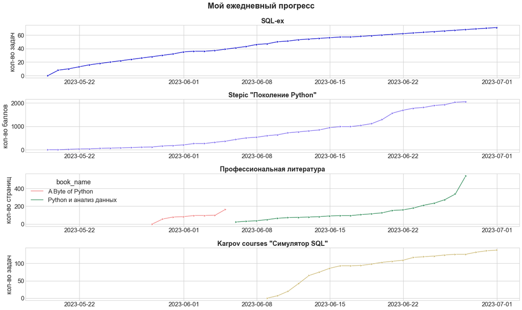

```python
plt.figure(figsize=(20, 12))
sns.set(font_scale=1.5)
plt.style.use('seaborn-whitegrid')
plt.suptitle('Мой ежедневный прогресс', fontweight='bold')

ax1 = plt.subplot(4, 1, 1)
sns.lineplot(data=df, x='date', y='sqlex_last_solved_task_number', marker='>', color='mediumblue')
plt.title('SQL-ex', fontweight='bold')
plt.xlabel('')
plt.ylabel('кол-во задач')

ax2 = plt.subplot(4, 1, 2, sharex = ax1)
sns.lineplot(data=df, x='date', y='stepic_python_current', marker='>', color='mediumslateblue')
plt.title('Stepic "Поколение Python"', fontweight='bold')
plt.xlabel('')
plt.ylabel('кол-во баллов')

ax3 = plt.subplot(4, 1, 3, sharex = ax1)
sns.lineplot(data=df, x='date', y='current_page', hue='book_name', marker='>',
             palette=['lightcoral', 'seagreen'])
plt.title('Профессиональная литература', fontweight='bold')
plt.xlabel('')
plt.ylabel('кол-во страниц')

ax4 = plt.subplot(4, 1, 4, sharex = ax1)
sns.lineplot(data=df, x='date', y='course_current', marker='>', color='y')
plt.title('Karpov courses "Симулятор SQL"', fontweight='bold')
plt.xlabel('')
plt.ylabel('кол-во задач')

plt.tight_layout()
plt.show();
```

### Общий прогресс в процентах

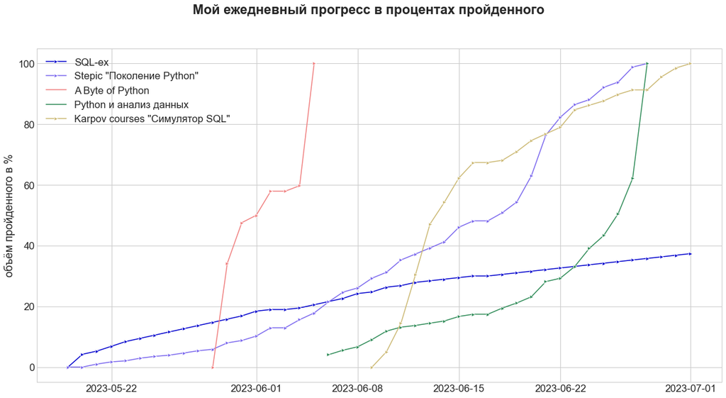

```python
plt.figure(figsize=(20, 10))
sns.set(font_scale=1.5)
plt.style.use('seaborn-whitegrid')
plt.suptitle('Мой ежедневный прогресс в процентах пройденного', fontweight='bold')

sns.lineplot(data=df, x='date', y='sqlex_percent', color='mediumblue', marker='>', label='SQL-ex')
sns.lineplot(data=df, x='date', y='stepic_percent', color='mediumslateblue', marker='>', label='Stepic "Поколение Python"')
sns.lineplot(data=df, x='date', y='book_percent', hue='book_name', marker='>',
             palette=['lightcoral', 'seagreen'])
sns.lineplot(data=df, x='date', y='course_percent', color='y', marker='>', label='Karpov courses "Симулятор SQL"')
plt.xlabel('')
plt.ylabel('объём пройденного в %')

plt.show();
```

### Расчёт KPI для завершения в срок

```python
d = dt.datetime.strptime("03-07-2023", "%d-%m-%Y")
d = d.date()
print('Предполагаемая дата завершения:', d)

days_remain = d - dt.date.today()
days_remain_number = str(days_remain).split('days')[0].strip()
print('Осталось:', days_remain_number, 'дней')
print()

df_today = df.loc[df['date'] == df['date'].max()]

goal_course = (df_today['course_total'].max() - df_today['course_current'].max()) / int(days_remain_number)
if pd.isnull(goal_course)==True:
    goal_course = 0.0
print('Karpov courses "Симулятор SQL"')
print('В день нужно пройти:', goal_course)
print()
goal_stepic = (df_today['stepic_python_total'].max() - df_today['stepic_python_current'].max()) / int(days_remain_number)
if pd.isnull(goal_stepic)==True:
    goal_stepic = 0.0
print('Stepic "Поколение Python"')
print('В день нужно пройти:', goal_stepic)
print()
goal_book = (df_today['total_page'].max() - df_today['current_page'].max()) / int(days_remain_number)
if pd.isnull(goal_book)==True:
    goal_book = 0.0
print('Профессиональная литература')
print('В день нужно пройти:', goal_book)
print()
goal_total = goal_course + goal_stepic + goal_book
print('Значение KPI в сумме')
print('В день нужно пройти:', goal_total)
```

```
Предполагаемая дата завершения: 2023-07-03
Осталось: 2 дней

Karpov courses "Симулятор SQL"
В день нужно пройти: 0.0

Stepic "Поколение Python"
В день нужно пройти: 0.0

Профессиональная литература
В день нужно пройти: 0.0

Значение KPI в сумме
В день нужно пройти: 0.0
```

### Ежедневный прогресс: среднее, медиана, KPI

Задаём ежедневный KPI как рассчитанный средний объём из предыдущего шага, плюс добавляем ежедневную задачу из SQL-ex.

```python
sqlex_kpi = 1
course_kpi = goal_course
stepic_python_kpi = goal_stepic
book_kpi = goal_book

total_kpi = sqlex_kpi + course_kpi + stepic_python_kpi + book_kpi
```

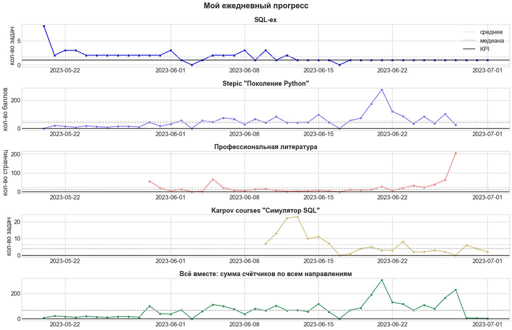

```python
plt.figure(figsize=(20, 13))
sns.set(font_scale=1.5)
plt.style.use('seaborn-whitegrid')
plt.suptitle('Мой ежедневный прогресс', fontweight='bold')

ax1 = plt.subplot(5, 1, 1)
sns.lineplot(data=df, x='date', y='sqlex_day_cnt', color='mediumblue', marker='s', linewidth=2)
plt.title('SQL-ex', fontweight='bold')
plt.xlabel('')
plt.ylabel('кол-во задач')
plt.axhline(y=df['sqlex_day_cnt'].mean(), color='lightgrey', linestyle='--', label='среднее')
plt.axhline(y=df['sqlex_day_cnt'].median(), color='darkgrey', linestyle='--', label='медиана')
plt.axhline(y=sqlex_kpi, color='black', linestyle='-', label='KPI')
plt.legend(loc='upper right')

ax2 = plt.subplot(5, 1, 2, sharex=ax1)
sns.lineplot(data=df, x='date', y='stepic_python_day_cnt', color='mediumslateblue', marker='s', linewidth=2)
plt.title('Stepic "Поколение Python"', fontweight='bold')
plt.xlabel('')
plt.ylabel('кол-во баллов')
plt.axhline(y=df['stepic_python_day_cnt'].mean(), color='lightgrey', linestyle='--', label='среднее')
plt.axhline(y=df['stepic_python_day_cnt'].median(), color='darkgrey', linestyle='--', label='медиана')
plt.axhline(y=stepic_python_kpi, color='black', linestyle='-', label='KPI')

ax3 = plt.subplot(5, 1, 3, sharex=ax1)
sns.lineplot(data=df, x='date', y='book_day_cnt', color='lightcoral', marker='s', linewidth=2)
plt.title('Профессиональная литература', fontweight='bold')
plt.xlabel('')
plt.ylabel('кол-во страниц')
plt.axhline(y=df['book_day_cnt'].mean(), color='lightgrey', linestyle='--', label='среднее')
plt.axhline(y=df['book_day_cnt'].median(), color='darkgrey', linestyle='--', label='медиана')
plt.axhline(y=book_kpi, color='black', linestyle='-', label='KPI')

ax4 = plt.subplot(5, 1, 4, sharex=ax1)
sns.lineplot(data=df, x='date', y='course_day_cnt', color='y', marker='s', linewidth=2)
plt.title('Karpov courses "Симулятор SQL"', fontweight='bold')
plt.xlabel('')
plt.ylabel('кол-во задач')
plt.axhline(y=df['course_day_cnt'].mean(), color='lightgrey', linestyle='--', label='среднее')
plt.axhline(y=df['course_day_cnt'].median(), color='darkgrey', linestyle='--', label='медиана')
plt.axhline(y=course_kpi, color='black', linestyle='-', label='KPI')

df['course_day_cnt'] = df['course_day_cnt'].fillna(0)
df['book_day_cnt'] = df['book_day_cnt'].fillna(0)
df['stepic_python_day_cnt'] = df['stepic_python_day_cnt'].fillna(0)
df['total_day_cnt'] = (df['sqlex_day_cnt'] + df['course_day_cnt'] + df['stepic_python_day_cnt'] +
                       df['book_day_cnt'])

ax5 = plt.subplot(5, 1, 5, sharex=ax1)
sns.lineplot(data=df, x='date', y='total_day_cnt', color='seagreen', marker='s', linewidth=2)
plt.title('Всё вместе: сумма счётчиков по всем направлениям', fontweight='bold')
plt.xlabel('')
plt.ylabel('')
plt.axhline(y=df['total_day_cnt'].mean(), color='lightgrey', linestyle='--', label='среднее')
plt.axhline(y=df['total_day_cnt'].median(), color='darkgrey', linestyle='--', label='медиана')
plt.axhline(y=total_kpi, color='black', linestyle='-', label='KPI')

plt.tight_layout()
plt.show();
```

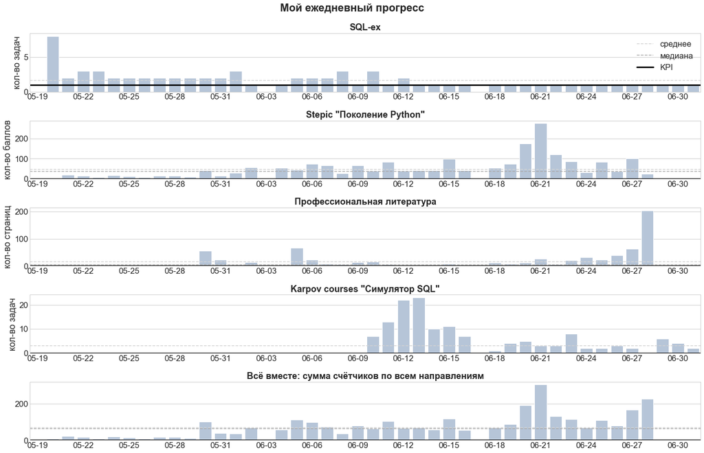

```python
plt.figure(figsize=(20, 13))
sns.set(font_scale=1.5)
plt.style.use('seaborn-whitegrid')
plt.suptitle('Мой ежедневный прогресс', fontweight='bold')

ticklabels = ['']*len(df)
skip = len(df)//12
ticklabels[::skip] = df['date'].iloc[::skip].dt.strftime('%m-%d')

def fmt(x, pos=0, max_i=len(ticklabels)-1):
    i = int(x)
    i = 0 if i < 0 else max_i if i > max_i else i
    return dates[i]

ax1 = plt.subplot(5, 1, 1)
sns.barplot(data=df, x='date', y='sqlex_day_cnt', color='lightsteelblue')
plt.title('SQL-ex', fontweight='bold')
plt.xlabel('')
plt.ylabel('кол-во задач')
plt.axhline(y=df['sqlex_day_cnt'].mean(), color='lightgrey', linestyle='--', label='среднее')
plt.axhline(y=df['sqlex_day_cnt'].median(), color='darkgrey', linestyle='--', label='медиана')
plt.axhline(y=sqlex_kpi, color='black', linestyle='-', label='KPI', linewidth=3)
plt.legend(loc='upper right')
ax1.xaxis.set_major_formatter(mticker.FixedFormatter(ticklabels))
ax1.fmt_xdata = fmt

ax2 = plt.subplot(5, 1, 2)
sns.barplot(data=df, x='date', y='stepic_python_day_cnt', color='lightsteelblue')
plt.title('Stepic "Поколение Python"', fontweight='bold')
plt.xlabel('')
plt.ylabel('кол-во баллов')
plt.axhline(y=df['stepic_python_day_cnt'].mean(), color='lightgrey', linestyle='--', label='среднее')
plt.axhline(y=df['stepic_python_day_cnt'].median(), color='darkgrey', linestyle='--', label='медиана')
plt.axhline(y=stepic_python_kpi, color='black', linestyle='-', label='KPI', linewidth=3)
ax2.xaxis.set_major_formatter(mticker.FixedFormatter(ticklabels))
ax2.fmt_xdata = fmt

ax3 = plt.subplot(5, 1, 3)
sns.barplot(data=df, x='date', y='book_day_cnt', color='lightsteelblue')
plt.title('Профессиональная литература', fontweight='bold')
plt.xlabel('')
plt.ylabel('кол-во страниц')
plt.axhline(y=df['book_day_cnt'].mean(), color='lightgrey', linestyle='--', label='среднее')
plt.axhline(y=df['book_day_cnt'].median(), color='darkgrey', linestyle='--', label='медиана')
plt.axhline(y=book_kpi, color='black', linestyle='-', label='KPI', linewidth=3)
ax3.xaxis.set_major_formatter(mticker.FixedFormatter(ticklabels))
ax3.fmt_xdata = fmt

ax4 = plt.subplot(5, 1, 4)
sns.barplot(data=df, x='date', y='course_day_cnt', color='lightsteelblue')
plt.title('Karpov courses "Симулятор SQL"', fontweight='bold')
plt.xlabel('')
plt.ylabel('кол-во задач')
plt.axhline(y=df['course_day_cnt'].mean(), color='lightgrey', linestyle='--', label='среднее')
plt.axhline(y=df['course_day_cnt'].median(), color='darkgrey', linestyle='--', label='медиана')
plt.axhline(y=course_kpi, color='black', linestyle='-', label='KPI', linewidth=3)
ax4.xaxis.set_major_formatter(mticker.FixedFormatter(ticklabels))
ax4.fmt_xdata = fmt

ax5 = plt.subplot(5, 1, 5)
sns.barplot(data=df, x='date', y='total_day_cnt', color='lightsteelblue')
plt.title('Всё вместе: сумма счётчиков по всем направлениям', fontweight='bold')
plt.xlabel('')
plt.ylabel('')
plt.axhline(y=df['total_day_cnt'].mean(), color='lightgrey', linestyle='--', label='среднее')
plt.axhline(y=df['total_day_cnt'].median(), color='darkgrey', linestyle='--', label='медиана')
plt.axhline(y=total_kpi, color='black', linestyle='-', label='KPI', linewidth=3)
ax5.xaxis.set_major_formatter(mticker.FixedFormatter(ticklabels))
ax5.fmt_xdata = fmt

plt.tight_layout()
plt.show();
```

### SQL-ex

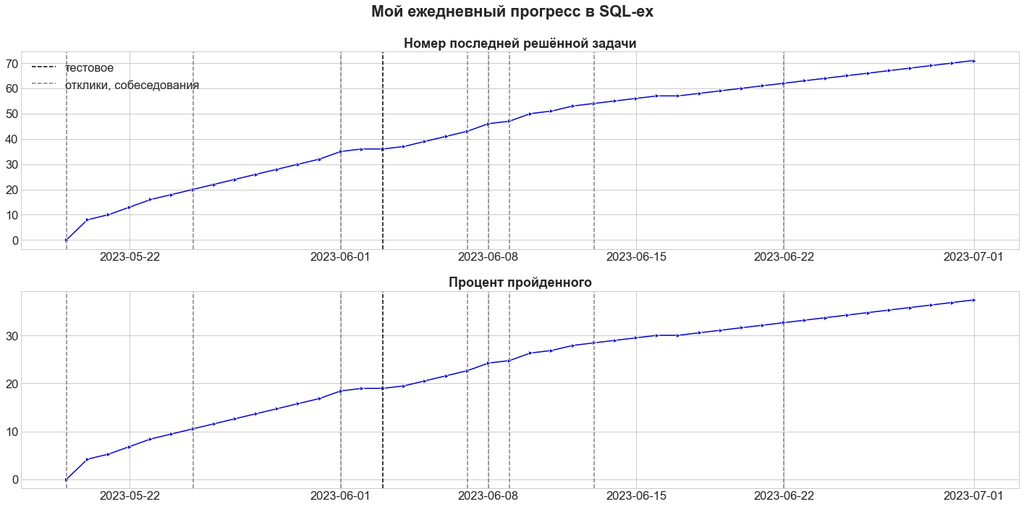

```python
plt.figure(figsize=(20, 10))
sns.set(font_scale=1.5)
plt.style.use('seaborn-whitegrid')
plt.suptitle('Мой ежедневный прогресс в SQL-ex', fontweight='bold')

ax1 = plt.subplot(2, 1, 1)
sns.lineplot(data=df, x='date', y='sqlex_last_solved_task_number', marker='>', color='mediumblue')

plt.axvline(x = df.query('career_activity_type == "тестовое"').iloc[0][['date']],
            color='black', linestyle='--', label='тестовое')
plt.axvline(x = df.query('career_activity_type != "нет" & career_activity_type != "тестовое"').iloc[0][['date']],
            color='grey', linestyle='--', label='отклики, собеседования')
plt.axvline(x = df.query('career_activity_type != "нет" & career_activity_type != "тестовое"').iloc[1][['date']],
            color='grey', linestyle='--')
plt.axvline(x = df.query('career_activity_type != "нет" & career_activity_type != "тестовое"').iloc[2][['date']],
            color='grey', linestyle='--')
plt.axvline(x = df.query('career_activity_type != "нет" & career_activity_type != "тестовое"').iloc[3][['date']],
            color='grey', linestyle='--')
plt.axvline(x = df.query('career_activity_type != "нет" & career_activity_type != "тестовое"').iloc[4][['date']],
            color='grey', linestyle='--')
plt.axvline(x = df.query('career_activity_type != "нет" & career_activity_type != "тестовое"').iloc[5][['date']],
            color='grey', linestyle='--')
plt.axvline(x = df.query('career_activity_type != "нет" & career_activity_type != "тестовое"').iloc[6][['date']],
            color='grey', linestyle='--')
plt.axvline(x = df.query('career_activity_type != "нет" & career_activity_type != "тестовое"').iloc[7][['date']],
            color='grey', linestyle='--')
plt.legend(loc='upper left')

plt.title('Номер последней решённой задачи', fontweight='bold')
plt.xlabel('')
plt.ylabel('')

ax2 = plt.subplot(2, 1, 2)
sns.lineplot(data=df, x='date', y='sqlex_percent', marker='>', color='mediumblue')

plt.axvline(x = df.query('career_activity_type == "тестовое"').iloc[0][['date']],
            color='black', linestyle='--')
plt.axvline(x = df.query('career_activity_type != "нет" & career_activity_type != "тестовое"').iloc[0][['date']],
            color='grey', linestyle='--')
plt.axvline(x = df.query('career_activity_type != "нет" & career_activity_type != "тестовое"').iloc[1][['date']],
            color='grey', linestyle='--')
plt.axvline(x = df.query('career_activity_type != "нет" & career_activity_type != "тестовое"').iloc[2][['date']],
            color='grey', linestyle='--')
plt.axvline(x = df.query('career_activity_type != "нет" & career_activity_type != "тестовое"').iloc[3][['date']],
            color='grey', linestyle='--')
plt.axvline(x = df.query('career_activity_type != "нет" & career_activity_type != "тестовое"').iloc[4][['date']],
            color='grey', linestyle='--')
plt.axvline(x = df.query('career_activity_type != "нет" & career_activity_type != "тестовое"').iloc[5][['date']],
            color='grey', linestyle='--')
plt.axvline(x = df.query('career_activity_type != "нет" & career_activity_type != "тестовое"').iloc[6][['date']],
            color='grey', linestyle='--')
plt.axvline(x = df.query('career_activity_type != "нет" & career_activity_type != "тестовое"').iloc[7][['date']],
            color='grey', linestyle='--')

plt.title('Процент пройденного', fontweight='bold')
plt.xlabel('')
plt.ylabel('')

plt.tight_layout()
plt.show();
```

### Stepic "Поколение Python"

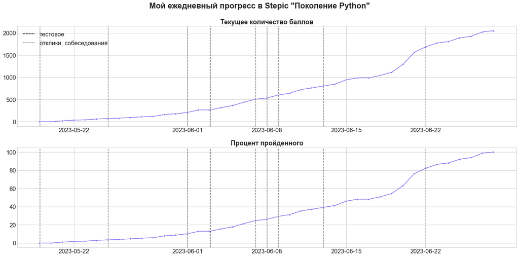

```python
plt.figure(figsize=(20, 10))
sns.set(font_scale=1.5)
plt.style.use('seaborn-whitegrid')
plt.suptitle('Мой ежедневный прогресс в Stepic "Поколение Python"', fontweight='bold')

ax1 = plt.subplot(2, 1, 1)
sns.lineplot(data=df, x='date', y='stepic_python_current', marker='>', color='mediumslateblue')

plt.axvline(x = df.query('career_activity_type == "тестовое"').iloc[0][['date']],
            color='black', linestyle='--', label='тестовое')
plt.axvline(x = df.query('career_activity_type != "нет" & career_activity_type != "тестовое"').iloc[0][['date']],
            color='grey', linestyle='--', label='отклики, собеседования')
plt.axvline(x = df.query('career_activity_type != "нет" & career_activity_type != "тестовое"').iloc[1][['date']],
            color='grey', linestyle='--')
plt.axvline(x = df.query('career_activity_type != "нет" & career_activity_type != "тестовое"').iloc[2][['date']],
            color='grey', linestyle='--')
plt.axvline(x = df.query('career_activity_type != "нет" & career_activity_type != "тестовое"').iloc[3][['date']],
            color='grey', linestyle='--')
plt.axvline(x = df.query('career_activity_type != "нет" & career_activity_type != "тестовое"').iloc[4][['date']],
            color='grey', linestyle='--')
plt.axvline(x = df.query('career_activity_type != "нет" & career_activity_type != "тестовое"').iloc[5][['date']],
            color='grey', linestyle='--')
plt.axvline(x = df.query('career_activity_type != "нет" & career_activity_type != "тестовое"').iloc[6][['date']],
            color='grey', linestyle='--')
plt.axvline(x = df.query('career_activity_type != "нет" & career_activity_type != "тестовое"').iloc[7][['date']],
            color='grey', linestyle='--')
plt.legend(loc='upper left')

plt.title('Текущее количество баллов', fontweight='bold')
plt.xlabel('')
plt.ylabel('')

ax2 = plt.subplot(2, 1, 2)
sns.lineplot(data=df, x='date', y='stepic_percent', marker='>', color='mediumslateblue')

plt.axvline(x = df.query('career_activity_type == "тестовое"').iloc[0][['date']],
            color='black', linestyle='--')
plt.axvline(x = df.query('career_activity_type != "нет" & career_activity_type != "тестовое"').iloc[0][['date']],
            color='grey', linestyle='--')
plt.axvline(x = df.query('career_activity_type != "нет" & career_activity_type != "тестовое"').iloc[1][['date']],
            color='grey', linestyle='--')
plt.axvline(x = df.query('career_activity_type != "нет" & career_activity_type != "тестовое"').iloc[2][['date']],
            color='grey', linestyle='--')
plt.axvline(x = df.query('career_activity_type != "нет" & career_activity_type != "тестовое"').iloc[3][['date']],
            color='grey', linestyle='--')
plt.axvline(x = df.query('career_activity_type != "нет" & career_activity_type != "тестовое"').iloc[4][['date']],
            color='grey', linestyle='--')
plt.axvline(x = df.query('career_activity_type != "нет" & career_activity_type != "тестовое"').iloc[5][['date']],
            color='grey', linestyle='--')
plt.axvline(x = df.query('career_activity_type != "нет" & career_activity_type != "тестовое"').iloc[6][['date']],
            color='grey', linestyle='--')
plt.axvline(x = df.query('career_activity_type != "нет" & career_activity_type != "тестовое"').iloc[7][['date']],
            color='grey', linestyle='--')

plt.title('Процент пройденного', fontweight='bold')
plt.xlabel('')
plt.ylabel('')

plt.tight_layout()
plt.show();
```

### Профессиональная литература

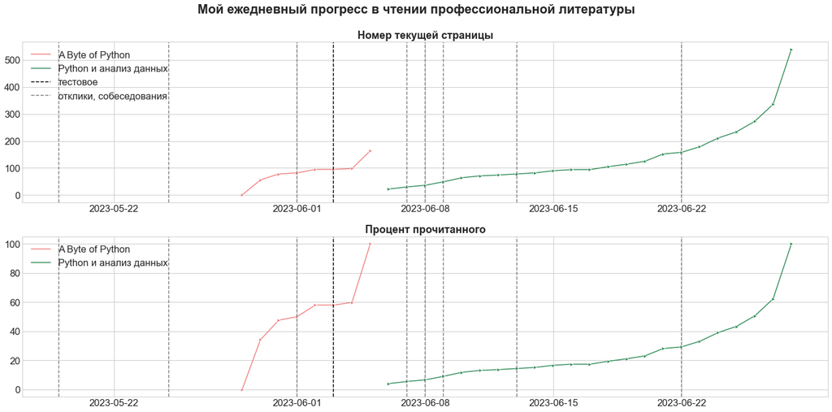

```python
plt.figure(figsize=(20, 10))
sns.set(font_scale=1.5)
plt.style.use('seaborn-whitegrid')
plt.suptitle('Мой ежедневный прогресс в чтении профессиональной литературы', fontweight='bold')

ax1 = plt.subplot(2, 1, 1)
sns.lineplot(data=df, x='date', y='current_page', hue='book_name', marker='>',
             palette=['lightcoral', 'seagreen'])

plt.axvline(x = df.query('career_activity_type == "тестовое"').iloc[0][['date']],
            color='black', linestyle='--', label='тестовое')
plt.axvline(x = df.query('career_activity_type != "нет" & career_activity_type != "тестовое"').iloc[0][['date']],
            color='grey', linestyle='--', label='отклики, собеседования')
plt.axvline(x = df.query('career_activity_type != "нет" & career_activity_type != "тестовое"').iloc[1][['date']],
            color='grey', linestyle='--')
plt.axvline(x = df.query('career_activity_type != "нет" & career_activity_type != "тестовое"').iloc[2][['date']],
            color='grey', linestyle='--')
plt.axvline(x = df.query('career_activity_type != "нет" & career_activity_type != "тестовое"').iloc[3][['date']],
            color='grey', linestyle='--')
plt.axvline(x = df.query('career_activity_type != "нет" & career_activity_type != "тестовое"').iloc[4][['date']],
            color='grey', linestyle='--')
plt.axvline(x = df.query('career_activity_type != "нет" & career_activity_type != "тестовое"').iloc[5][['date']],
            color='grey', linestyle='--')
plt.axvline(x = df.query('career_activity_type != "нет" & career_activity_type != "тестовое"').iloc[6][['date']],
            color='grey', linestyle='--')
plt.axvline(x = df.query('career_activity_type != "нет" & career_activity_type != "тестовое"').iloc[7][['date']],
            color='grey', linestyle='--')
plt.legend(loc='upper left')

plt.title('Номер текущей страницы', fontweight='bold')
plt.xlabel('')
plt.ylabel('')

ax2 = plt.subplot(2, 1, 2)
sns.lineplot(data=df, x='date', y='book_percent', hue='book_name', marker='>',
            palette=['lightcoral', 'seagreen'])

plt.axvline(x = df.query('career_activity_type == "тестовое"').iloc[0][['date']],
            color='black', linestyle='--')
plt.axvline(x = df.query('career_activity_type != "нет" & career_activity_type != "тестовое"').iloc[0][['date']],
            color='grey', linestyle='--')
plt.axvline(x = df.query('career_activity_type != "нет" & career_activity_type != "тестовое"').iloc[1][['date']],
            color='grey', linestyle='--')
plt.axvline(x = df.query('career_activity_type != "нет" & career_activity_type != "тестовое"').iloc[2][['date']],
            color='grey', linestyle='--')
plt.axvline(x = df.query('career_activity_type != "нет" & career_activity_type != "тестовое"').iloc[3][['date']],
            color='grey', linestyle='--')
plt.axvline(x = df.query('career_activity_type != "нет" & career_activity_type != "тестовое"').iloc[4][['date']],
            color='grey', linestyle='--')
plt.axvline(x = df.query('career_activity_type != "нет" & career_activity_type != "тестовое"').iloc[5][['date']],
            color='grey', linestyle='--')
plt.axvline(x = df.query('career_activity_type != "нет" & career_activity_type != "тестовое"').iloc[6][['date']],
            color='grey', linestyle='--')
plt.axvline(x = df.query('career_activity_type != "нет" & career_activity_type != "тестовое"').iloc[7][['date']],
            color='grey', linestyle='--')
plt.legend(loc='upper left')

plt.title('Процент прочитанного', fontweight='bold')
plt.xlabel('')
plt.ylabel('')

plt.tight_layout()
plt.show();
```

### Karpov courses "Симулятор SQL"

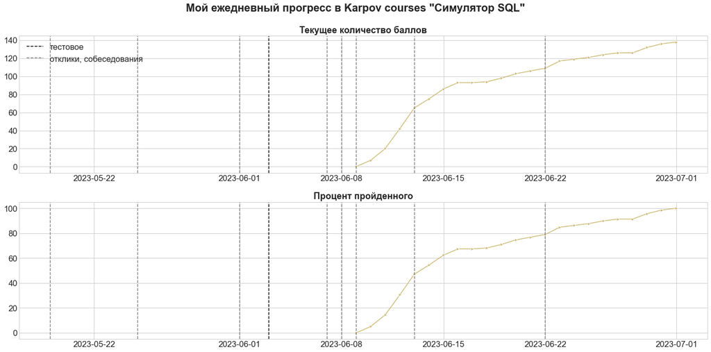

```python
plt.figure(figsize=(20, 10))
sns.set(font_scale=1.5)
plt.style.use('seaborn-whitegrid')
plt.suptitle('Мой ежедневный прогресс в Karpov courses "Симулятор SQL"', fontweight='bold')

ax1 = plt.subplot(2, 1, 1)
sns.lineplot(data=df, x='date', y='course_current', marker='>', color='y')

plt.axvline(x = df.query('career_activity_type == "тестовое"').iloc[0][['date']],
            color='black', linestyle='--', label='тестовое')
plt.axvline(x = df.query('career_activity_type != "нет" & career_activity_type != "тестовое"').iloc[0][['date']],
            color='grey', linestyle='--', label='отклики, собеседования')
plt.axvline(x = df.query('career_activity_type != "нет" & career_activity_type != "тестовое"').iloc[1][['date']],
            color='grey', linestyle='--')
plt.axvline(x = df.query('career_activity_type != "нет" & career_activity_type != "тестовое"').iloc[2][['date']],
            color='grey', linestyle='--')
plt.axvline(x = df.query('career_activity_type != "нет" & career_activity_type != "тестовое"').iloc[3][['date']],
            color='grey', linestyle='--')
plt.axvline(x = df.query('career_activity_type != "нет" & career_activity_type != "тестовое"').iloc[4][['date']],
            color='grey', linestyle='--')
plt.axvline(x = df.query('career_activity_type != "нет" & career_activity_type != "тестовое"').iloc[5][['date']],
            color='grey', linestyle='--')
plt.axvline(x = df.query('career_activity_type != "нет" & career_activity_type != "тестовое"').iloc[6][['date']],
            color='grey', linestyle='--')
plt.axvline(x = df.query('career_activity_type != "нет" & career_activity_type != "тестовое"').iloc[7][['date']],
            color='grey', linestyle='--')
plt.legend(loc='upper left')

plt.title('Текущее количество баллов', fontweight='bold')
plt.xlabel('')
plt.ylabel('')

ax2 = plt.subplot(2, 1, 2)
sns.lineplot(data=df, x='date', y='course_percent', marker='>', color='y')

plt.axvline(x = df.query('career_activity_type == "тестовое"').iloc[0][['date']],
            color='black', linestyle='--')
plt.axvline(x = df.query('career_activity_type != "нет" & career_activity_type != "тестовое"').iloc[0][['date']],
            color='grey', linestyle='--')
plt.axvline(x = df.query('career_activity_type != "нет" & career_activity_type != "тестовое"').iloc[1][['date']],
            color='grey', linestyle='--')
plt.axvline(x = df.query('career_activity_type != "нет" & career_activity_type != "тестовое"').iloc[2][['date']],
            color='grey', linestyle='--')
plt.axvline(x = df.query('career_activity_type != "нет" & career_activity_type != "тестовое"').iloc[3][['date']],
            color='grey', linestyle='--')
plt.axvline(x = df.query('career_activity_type != "нет" & career_activity_type != "тестовое"').iloc[4][['date']],
            color='grey', linestyle='--')
plt.axvline(x = df.query('career_activity_type != "нет" & career_activity_type != "тестовое"').iloc[5][['date']],
            color='grey', linestyle='--')
plt.axvline(x = df.query('career_activity_type != "нет" & career_activity_type != "тестовое"').iloc[6][['date']],
            color='grey', linestyle='--')
plt.axvline(x = df.query('career_activity_type != "нет" & career_activity_type != "тестовое"').iloc[7][['date']],
            color='grey', linestyle='--')

plt.title('Процент пройденного', fontweight='bold')
plt.xlabel('')
plt.ylabel('')

plt.tight_layout()
plt.show();
```

### Карьерная активность

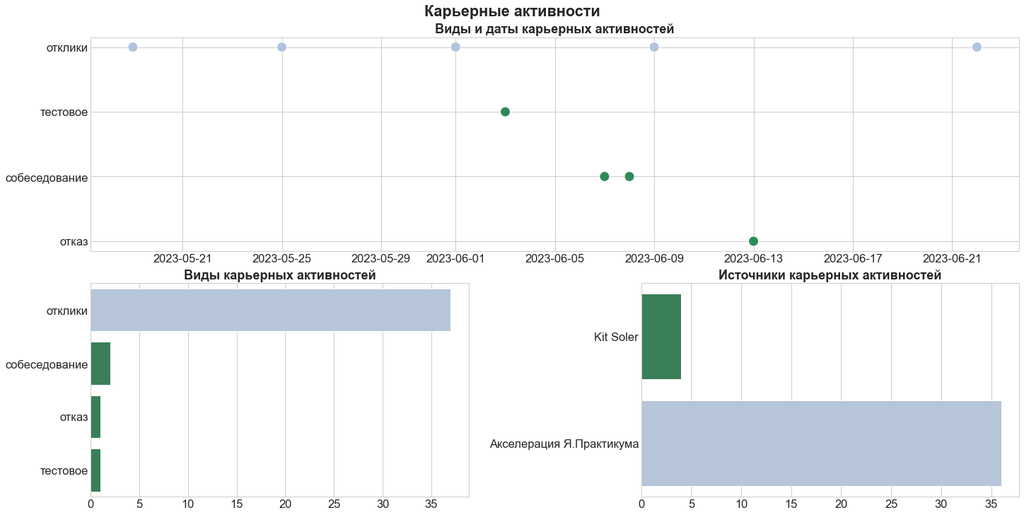

```python
fig = plt.figure(constrained_layout=True, figsize=(20, 10))
sns.set(font_scale=1.5)
plt.style.use('seaborn-whitegrid')
plt.suptitle('Карьерные активности', fontweight='bold')

spec = gridspec.GridSpec(ncols=2, nrows=2, figure=fig)

ax1 = fig.add_subplot(spec[0, :])
sns.scatterplot(data=df.query('career_activity_type != "нет"').sort_values(by='date'),
                 x='date', y='career_activity_type', s=200,
                 hue = 'career_activity_type', palette = ['lightsteelblue', 'seagreen', 'seagreen', 'seagreen'])
plt.title('Виды и даты карьерных активностей', fontweight='bold')
ax1.get_legend().remove()
plt.xlabel('')
plt.ylabel('')

ax2 = fig.add_subplot(spec[1, :-1])
sns.barplot(data=(df.query('career_activity_type != "нет"').groupby('career_activity_type', as_index=False)
                  .agg({'career_activity_number':'sum'}).sort_values(by='career_activity_number', ascending=False)),
            x='career_activity_number', y='career_activity_type',
            palette = ['lightsteelblue', 'seagreen', 'seagreen', 'seagreen'])
plt.title('Виды карьерных активностей', fontweight='bold')
plt.xlabel('')
plt.ylabel('')

ax3 = fig.add_subplot(spec[1, -1])
sns.barplot(data=(df.query('career_source != "нет"').groupby('career_source', as_index=False)
                  .agg({'career_activity_number':'sum'})), x='career_activity_number', y='career_source',
            palette = ['seagreen','lightsteelblue'])
plt.title('Источники карьерных активностей', fontweight='bold')
plt.xlabel('')
plt.ylabel('')


plt.show();
```

### Практика английского языка

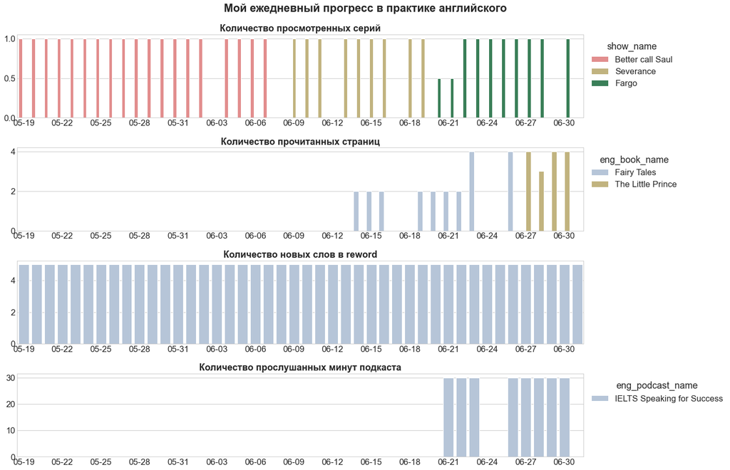

```python
plt.figure(figsize=(20, 13))
sns.set(font_scale=1.5)
plt.style.use('seaborn-whitegrid')
plt.suptitle('Мой ежедневный прогресс в практике английского', fontweight='bold')

# обрабатываем исключительный случай (когда книга на двух языках и англ текст идёт с середины книги)
df['eng_book_day_cnt'] = df['eng_book_day_cnt'].replace(103, 4)

ticklabels = ['']*len(df)
skip = len(df)//12
ticklabels[::skip] = df['date'].iloc[::skip].dt.strftime('%m-%d')

def fmt(x, pos=0, max_i=len(ticklabels)-1):
    i = int(x)
    i = 0 if i < 0 else max_i if i > max_i else i
    return dates[i]

ax1 = plt.subplot(4, 1, 1)
sns.barplot(data=df, x='date', y='serial_count', hue='show_name',
           palette=['lightcoral', 'y', 'seagreen'])
plt.title('Количество просмотренных серий', fontweight='bold')
plt.xlabel('')
plt.ylabel('')
sns.move_legend(ax1, "upper left", bbox_to_anchor=(1, 1))
ax1.xaxis.set_major_formatter(mticker.FixedFormatter(ticklabels))
ax1.fmt_xdata = fmt

ax2 = plt.subplot(4, 1, 2, sharex=ax1)
sns.barplot(data=df, x='date', y='eng_book_day_cnt', hue='eng_book_name',
            palette=['lightsteelblue', 'y'])
plt.title('Количество прочитанных страниц', fontweight='bold')
plt.xlabel('')
plt.ylabel('')
sns.move_legend(ax2, "upper left", bbox_to_anchor=(1, 1))
ax2.xaxis.set_major_formatter(mticker.FixedFormatter(ticklabels))
ax2.fmt_xdata = fmt

ax3 = plt.subplot(4, 1, 3, sharex=ax1)
sns.barplot(data=df, x='date', y='eng_new_words_in_reword', color='lightsteelblue')
plt.title('Количество новых слов в reword', fontweight='bold')
plt.xlabel('')
plt.ylabel('')
ax3.xaxis.set_major_formatter(mticker.FixedFormatter(ticklabels))
ax3.fmt_xdata = fmt

ax4 = plt.subplot(4, 1, 4, sharex=ax1)
sns.barplot(data=df, x='date', y='eng_podcast_minutes', hue = 'eng_podcast_name',
            palette=['lightsteelblue'])
plt.title('Количество прослушанных минут подкаста', fontweight='bold')
plt.xlabel('')
plt.ylabel('')
sns.move_legend(ax4, "upper left", bbox_to_anchor=(1, 1))
ax4.xaxis.set_major_formatter(mticker.FixedFormatter(ticklabels))
ax4.fmt_xdata = fmt

plt.tight_layout()
plt.show();
```

## Результаты 📜🎓

[figure not shown]

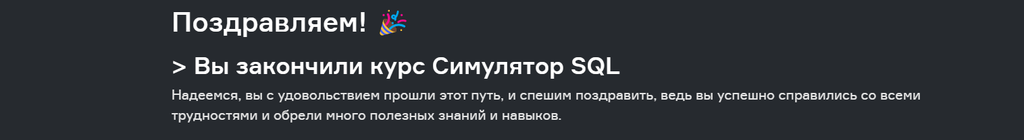

**Karpov courses "Симулятор SQL"**. Мои дашборды в **Redash**:

Дашборд по продукту: https://redash.public.karpov.courses/dashboards/1444-dashboard

Дашборд по продуктовым метрикам: https://redash.public.karpov.courses/dashboards/1461-dashboard-of-product-metrics

Дашборд по маркетинговым метрикам: https://redash.public.karpov.courses/dashboards/1466-dashboard-of-marketing-metrics

## Выводы

Ведение дневника профессионального роста помогает:

- структурировать динамику прохождения курсов и освоения прочего материала; избежать прокрастинации при постановке объёмных целей
- ориентироваться на ежедневную норму, автоматически обновляя расчёты KPI с учётом оставшегося объёма материала и времени
- делать прогресс наглядным и прозрачным
- поддерживать ежедневную мотивацию
- достигать целей в срок

Дневник своего профессионального прогресса ведёт: аналитик данных Малахова Наталья

Мой телеграм-канал: [Дневник аналитика](https://t.me/diary_musician_analyst)

Портфолио: [GitHub](https://github.com/Malakhova-Natalya)

LinkedIn: [Natalya Malakhova](https://www.linkedin.com/in/natalya-malakhova-324b81278/)

Спасибо за внимание!